# Time Series

Rahul Gupta

## Problem Statement & Data Analysis

#### *Congratulations on your new job! This time you are helping out Unicorn Investors with your data hacking skills. They are considering making an investment in a new form of transportation - JetRail. JetRail uses Jet propulsion technology to run rails and move people at a high speed! While JetRail has mastered the technology and they hold the patent for their product, the investment would only make sense, if they can get more than 1 Million monthly users with in next 18 months.*

#### *You need to help Unicorn ventures with the decision. They usually invest in B2C start-ups less than 4 years old looking for pre-series A funding. In order to help Unicorn Ventures in their decision, you need to forecast the traffic on JetRail for the next 7 months.*

#### Provided dataset has two columns one is the time column and the other one is represensting the number of passensgers travelled in the rail. Granularity of data is at ‘hour’, which means number of passengers travelled in rail each hour of the day. Data is available from 25th of August, 2012 midnight till 25th of September, 2014 midnight. This accounts for 18288 observations.

#### Top 5 and last 5 Observations in the dataset

```
##                     count
## 2012-08-25 00:00:00     8
## 2012-08-25 01:00:00     2
## 2012-08-25 02:00:00     6
## 2012-08-25 03:00:00     2
## 2012-08-25 04:00:00     2
## 2012-08-25 05:00:00     2
```

```
##                     count
## 2014-09-25 18:00:00   680
## 2014-09-25 19:00:00   868
## 2014-09-25 20:00:00   732
## 2014-09-25 21:00:00   702
## 2014-09-25 22:00:00   580
## 2014-09-25 23:00:00   534
```

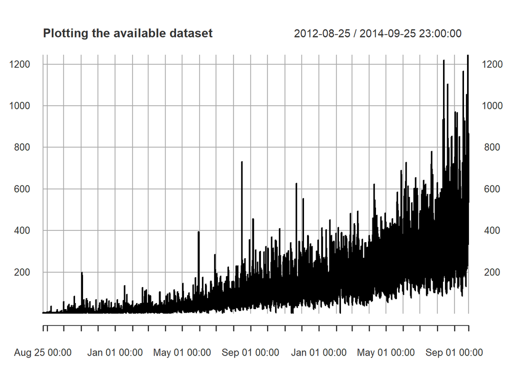

##### Since the data is at hourly level for two long years i.e. from end of August, 2012 to end of September, 2014. It is difficult to see the underlying pattern from the plot of whole dataset. But few initial observations are : there is an increasing trend and also increasing variance with time.

#### **Analyzing data at daily and monthly level**

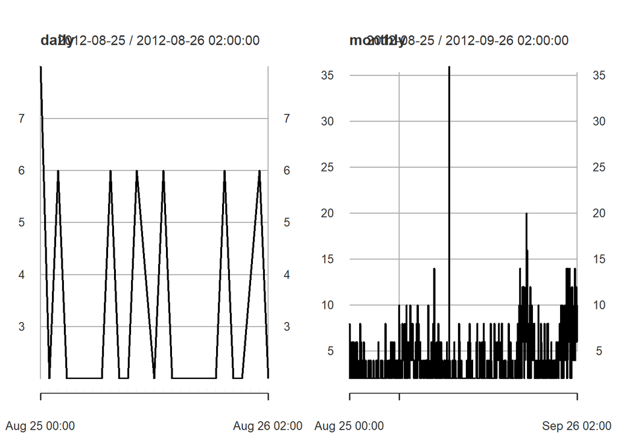

#### **Plotting logged and differencing data**

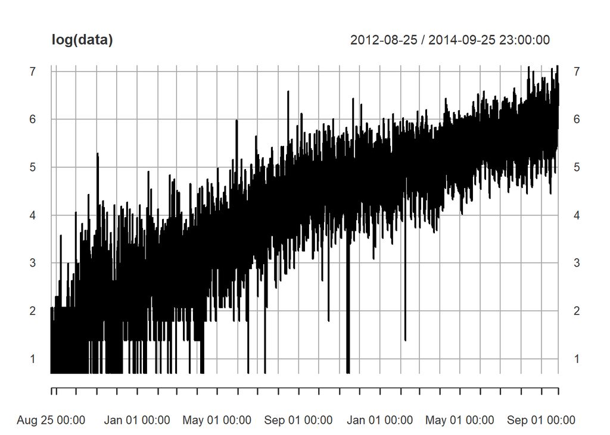

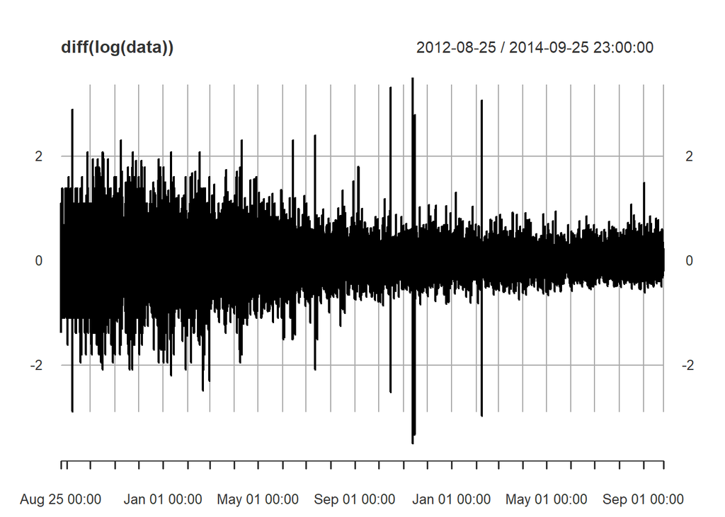

##### It seems after differencing the logged data, trend is removed but variablilty around mean is still an issue.

## ACF and PACF

##### **ACF and PACF of actual data**

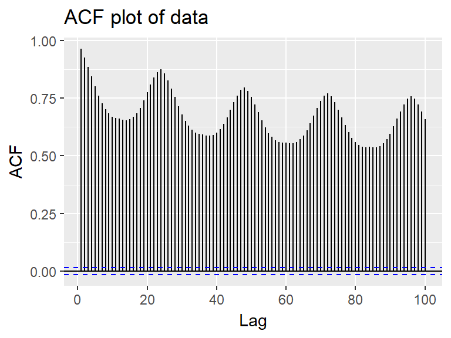

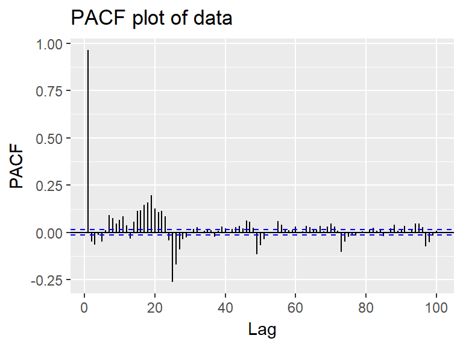

##### From the ACF plot we can see seasonlaity exists, with a period of 24 lags and PACF plots also show significant spikes till lag 24.

##### **ACF and PACF of differenced and logged data**

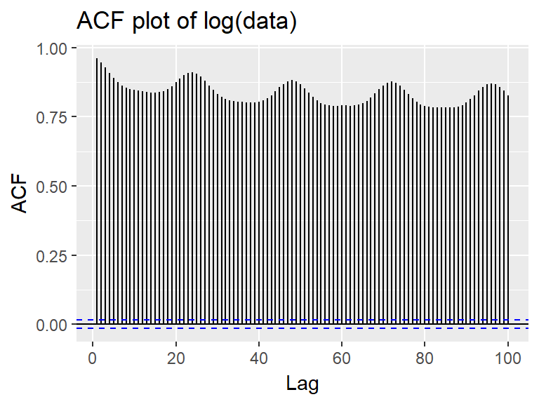

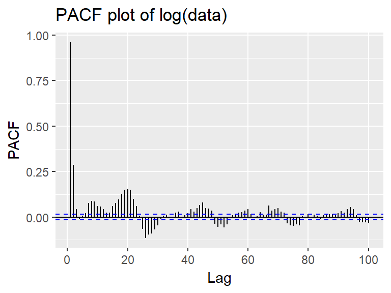

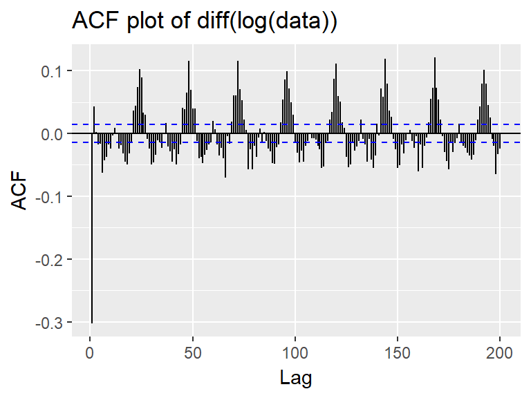

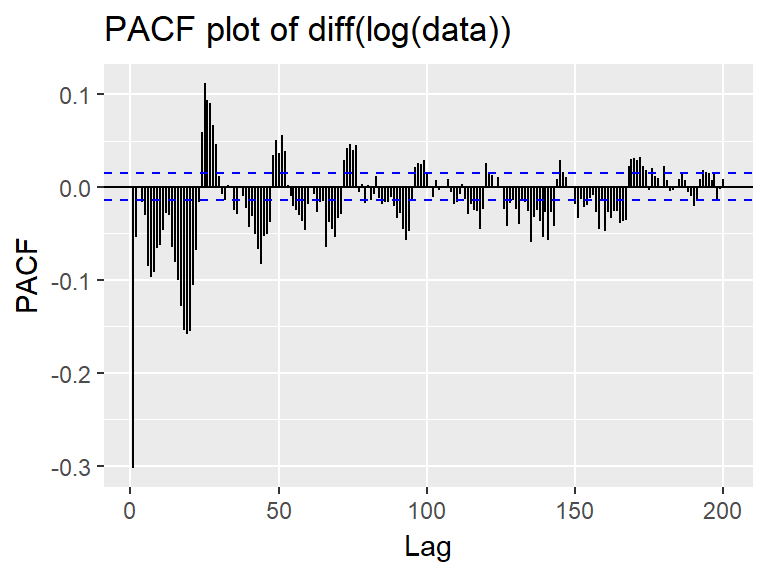

##### ACF and PACF plots of logged and differenced series are not helping much in uncovering the underlying phenomenon. All it is showing that there exists sesonality of 24 in the dataset. Since the dataset is at hour level and being a local transportion data, 24 hours of seasonality is seems to be a good finding. Because commuters go to office almost at the same time in the morning, so pattern repeats after 24 hours.

##### **ACF and PACF of actual data with differencing of 24 to see the seasonality effect**

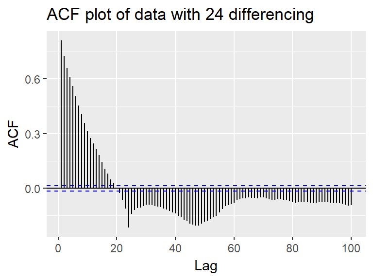

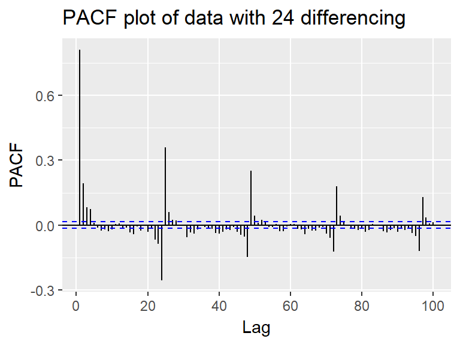

##### ACF plot of data with differencing (or lag differencing) value of 24 is tappering down and here again seasonality effect is visible at multiples of 24.

##### PACF also show a seasonality component at multiples of 24, with damping spikes at seasonality level but within seasonality period of 24, there are few significant spikes of the order of 2 or 4. So, it suggest an AR(2) or AR(4) base model

##### From the above observations, the suitable models that can be tried on this dataset are

#### **Seasonal ARIMA(p=2,d=0,q=0,P=1,D=1,Q=0,S=24)**

#### **Seasonal ARIMA(p=4,d=0,q=0,P=1,D=1,Q=0,S=24)**

#### **Seasonal ARIMA(p=2,d=0,q=0,P=1,D=1,Q=1,S=24)**

## Modeling

##### The potential models have been identified in the last discussion. But before fitting the models, let’s split the data into train and test, so that the model can be evaluated on paramters like RMSE, MAPE etc.

#### **Data Splitting**

##### Since the data is for almost two years i.e. from end of August, 2012 to end of September, 2014. Split of data was made in such a way that train dataset will contain data till June, 2014 and rest data of four months will be assigned to test dataset.

##### **This results in almost 85:15 train test split.**

##### **Model 1 : Seasonal ARIMA(p=2,d=0,q=0,P=1,D=1,Q=0,S=24)**

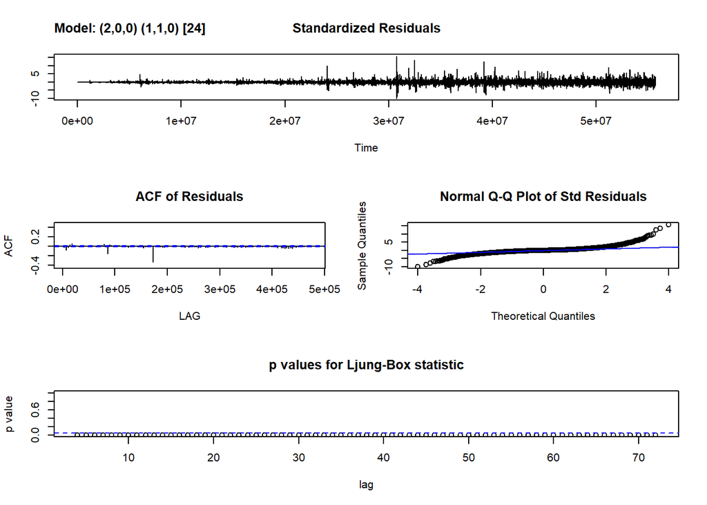

```
##          Estimate     SE  t.value p.value
## ar1        0.6498 0.0078  82.9060  0.0000
## ar2        0.2265 0.0078  28.9236  0.0000
## sar1      -0.4774 0.0071 -67.1624  0.0000
## constant   0.0123 0.0546   0.2242  0.8226
```

Value of AIC for the above model is 7.789093

Value of AIC for the above model is 6.7910682

##### **Model 2 : Seasonal ARIMA(p=4,d=0,q=0,P=1,D=1,Q=0,S=24)**

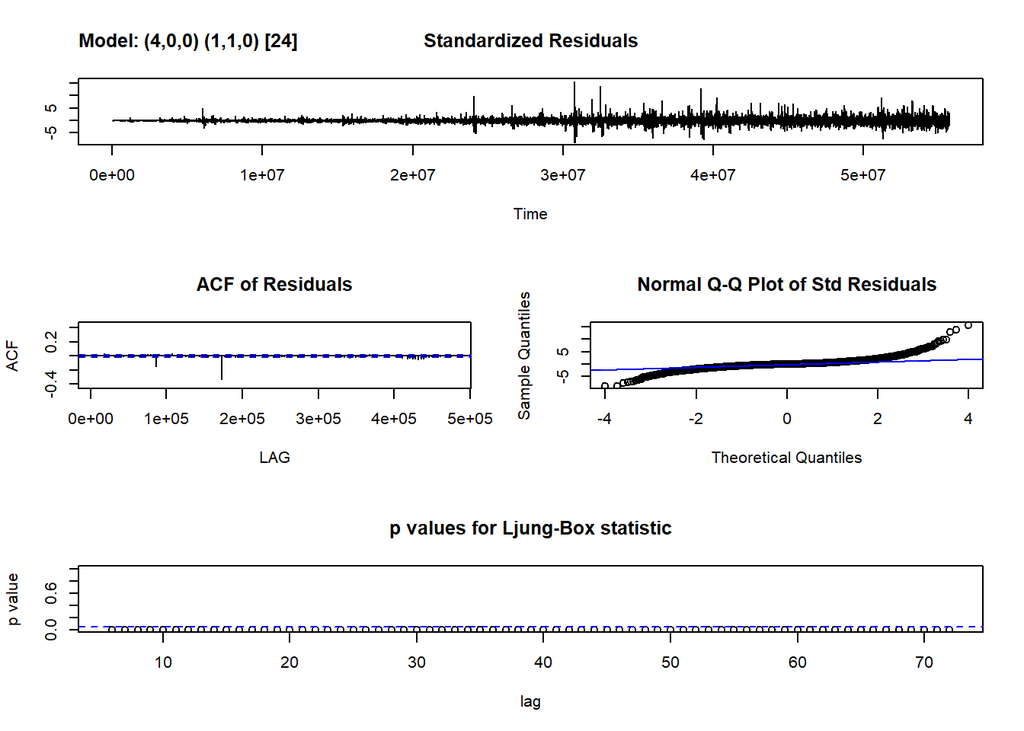

```
##          Estimate     SE  t.value p.value
## ar1        0.6273 0.0080  78.1114  0.0000
## ar2        0.1650 0.0095  17.4221  0.0000
## ar3        0.0381 0.0095   4.0221  0.0001
## ar4        0.0625 0.0080   7.7906  0.0000
## sar1      -0.4768 0.0071 -67.1407  0.0000
## constant   0.0122 0.0629   0.1948  0.8455
```

Value of AIC for the above model is 7.7793904

Value of AIC for the above model is 6.7823533

##### **Model 3 : Seasonal ARIMA(p=2,d=0,q=0,P=1,D=1,Q=1,S=24)**

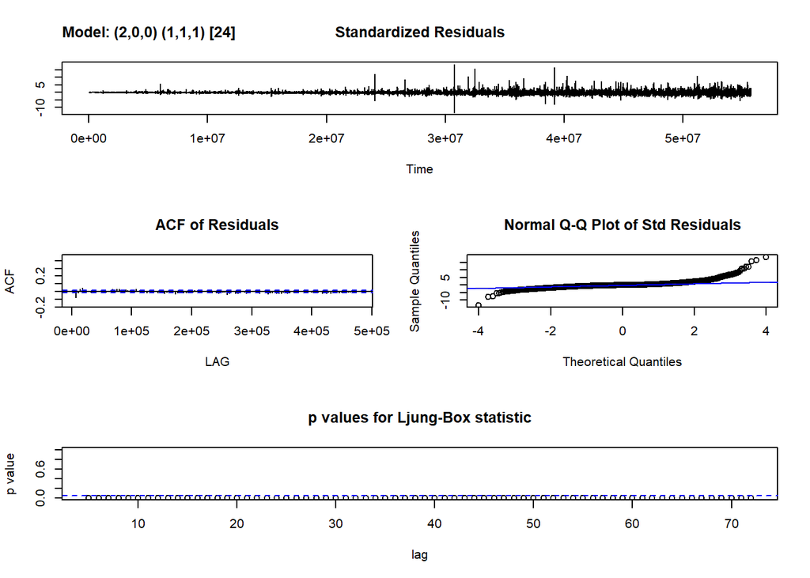

```
##          Estimate     SE   t.value p.value
## ar1        0.6535 0.0078   83.2488  0.0000
## ar2        0.2295 0.0078   29.2976  0.0000
## sar1       0.0139 0.0083    1.6713  0.0947
## sma1      -0.9678 0.0019 -506.3117  0.0000
## constant   0.0177 0.0024    7.3259  0.0000
```

Value of AIC for the above model is 7.4021226

Value of AIC for the above model is 6.4045917

#### Observations from the above models :

All three above models have performed similarly, if we consider thier AIC and BIC values. Model 3 i.e. **Seasonal ARIMA(p=2,d=0,q=0,P=1,D=1,Q=1,S=24)** is performing little better than other two. But the concern for all three models is that, there are still few spikes in the ACF of residuals and for none of the model there exist good p-values for Q statistics (or Ljung-Box statistics), which means we are still loosing the information in the residuals and it is not a white noise.

##### **Model 4 : TBATS(T for trigonometric regressors to model multiple-seasonalities, B for Box-Cox transformations, A for ARMA errors, T for trend, S for seasonality) model to handle multiple seasonality in the data**

##### Considering the business model of transportation industry, it is understood that there are two kinds of seasonality in the transportation data. One is at daily level and other one is at weekly level. Below model is built for two level of seasonality (i.e. daily and weekly) in data.

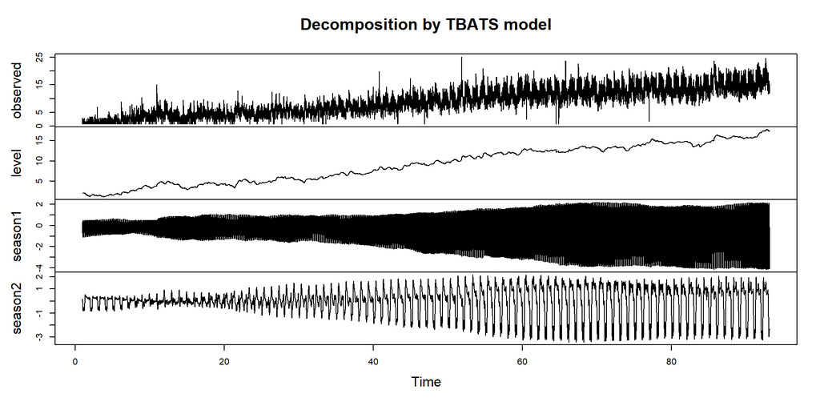

## Model Evaluation & Forecasting

##### In the modelling phase, four models were developed. In this section, these four models will be used to forecast for time range same as in the test dataset. This is done to evaluate the models by comparing the results with the test dataset. The parameter choosen to compare between the models is RMSE. Rule of RMSE is, lower the better. The model which will give the minimum RMSE will be used as a final model for prediction of number of passengers in the rail for next 7 months to make a decision whether to invest or not.

##### **Forecasting using Model 1 : Seasonal ARIMA(p=2,d=0,q=0,P=1,D=1,Q=0,S=24)**

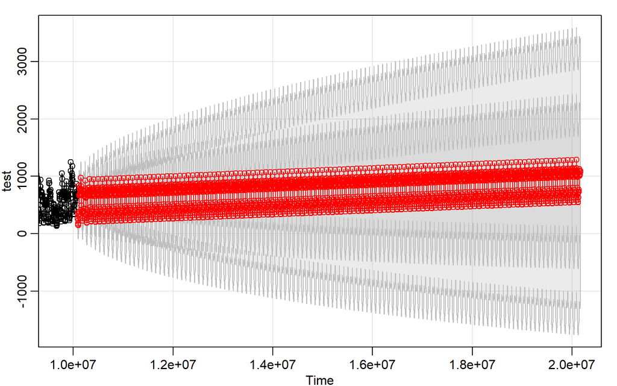

```
##                ME     RMSE      MAE       MPE     MAPE
## Test set -354.085 469.7579 399.7588 -150.8412 158.2232
```

##### **Forecasting using Model 2 : Seasonal ARIMA(p=4,d=0,q=0,P=1,D=1,Q=0,S=24)**

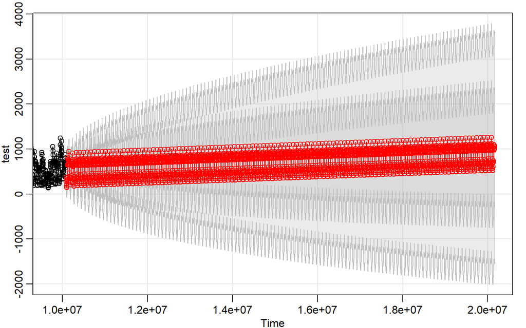

```
##                 ME     RMSE      MAE       MPE     MAPE
## Test set -330.0919 451.4614 382.9066 -143.0726 151.7925
```

##### **Forecasting using Model 3 : Seasonal ARIMA(p=2,d=0,q=0,P=1,D=1,Q=1,S=24)**

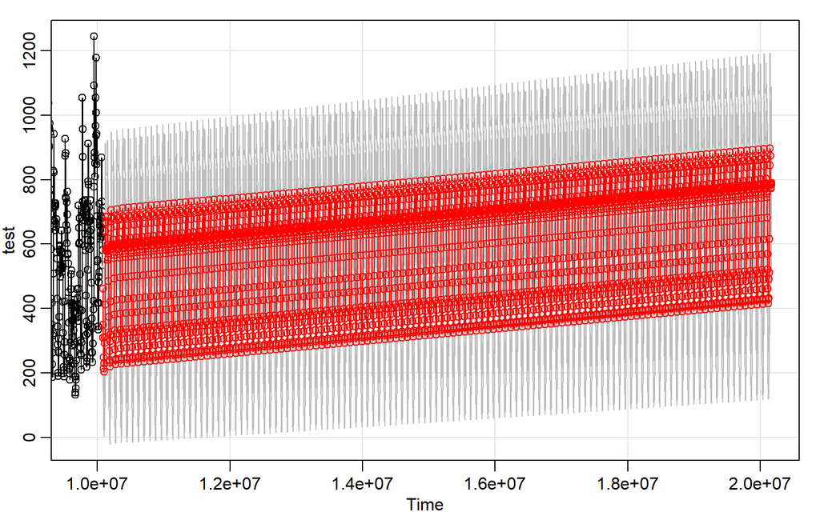

```
##                 ME     RMSE      MAE       MPE     MAPE
## Test set -209.8485 329.4717 285.2516 -100.5037 112.8311
```

##### **Forecasting using Model 4 : TBATS with daily and weekly seasonality**

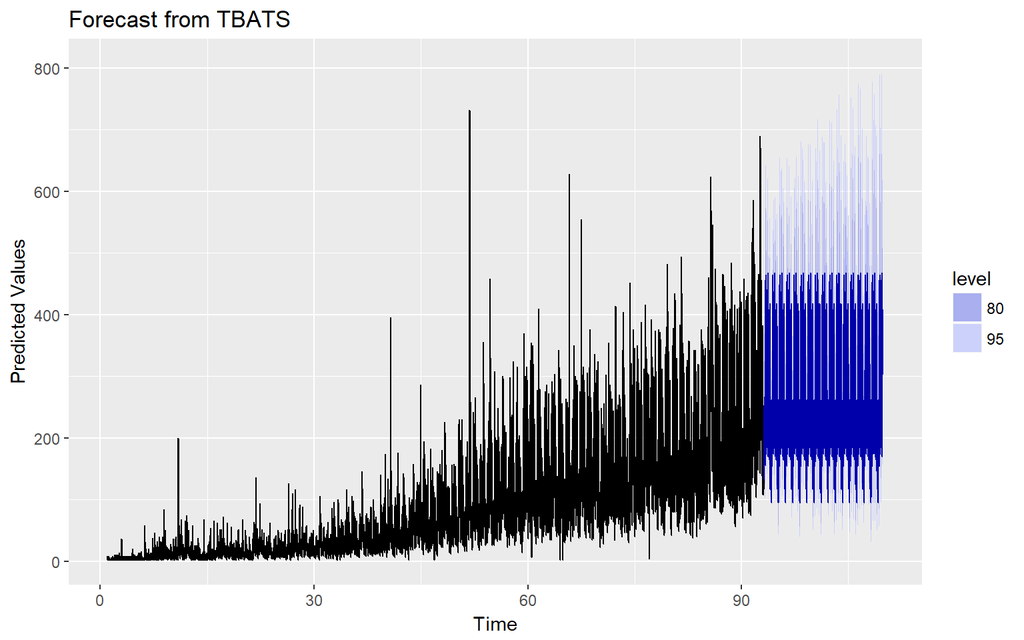

```
##               ME     RMSE      MAE      MPE     MAPE
## Test set 75.7057 140.5285 92.35543 13.55764 21.25754
```

##### **Observations from the forecasting results :**

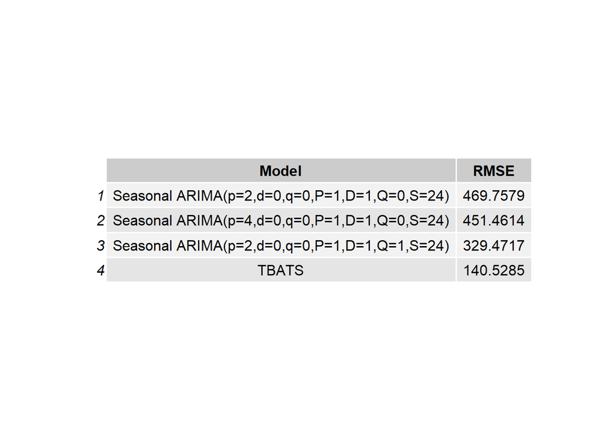

##### **TBATS model gives the best Test RMSE among all the models.**

#### TBATS model will be used for forecasting the number of passengers in rail for next 7 months as required by the business in order to make decision whether to invest in this new mode of transportation or not.

## Summary

### **Understanding the context of business case**

##### *Unicorn Investors are considering making an investment in a new form of transportation - JetRail. JetRail uses Jet propulsion technology to run rails and move people at a high speed! While JetRail has mastered the technology and they hold the patent for their product. **The investment would only make sense, if they can get more than 1 Million monthly users with in next 18 months.***

##### *Unicorn Investors usually invest in B2C start-ups less than 4 years old looking for pre-series A funding. This report will help Unicorn ventures in their decision, by forecasting the traffic on JetRail for the next 7 months. So by looking at the trend or growth rate of this mode of transporation for next seven months, Unicorn will have quantiative information before making decision that JetRail will be able to get more than 1 million users per month or not.*

##### **Plotting the JetRail growth from inseption till date**

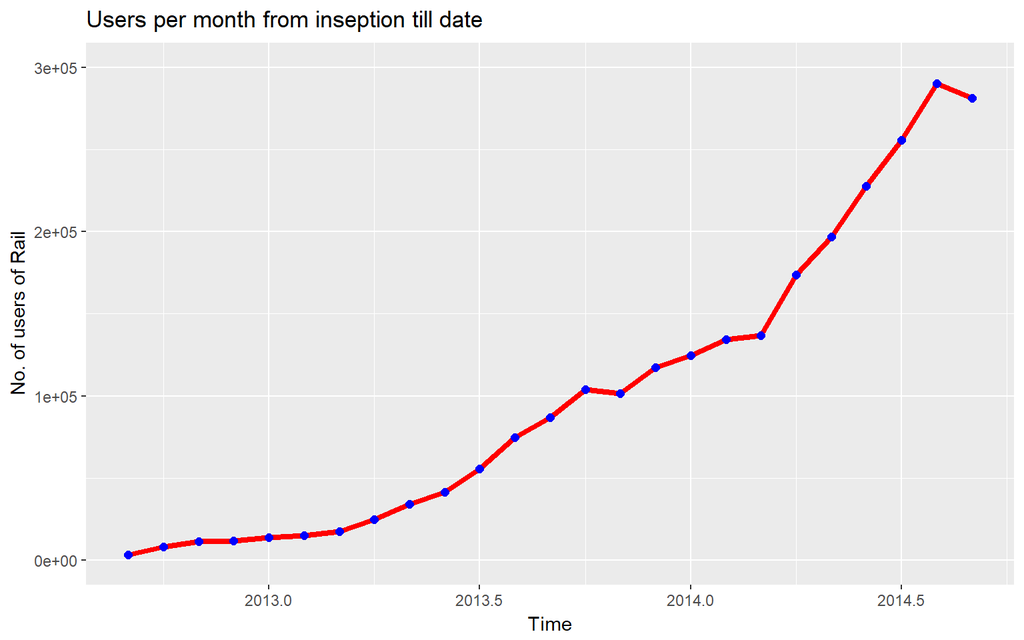

##### **Forecasting for next 7 months using the selected TBATS model**

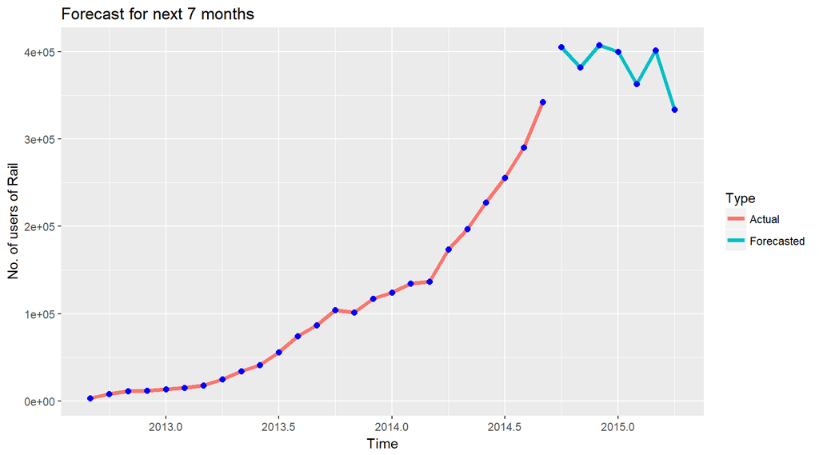

##### *The above forecast is not what was expected because it is not able to capture the increasing trend and the forecast is fluctuating near 0.4 million users of rail, which is not following the extisting pattern of last two years. What if, we look at this problem of forecasting the users in future from different perspective.*

##### *The new perspective is to ignore the seasonality and use aggregated data instead of hourly level, make the data to rollup to monthly level and then forecast directly at month level for future months. This approach might able to capture the high level trend of data. Let’s again reiterate our goal, the goal is to predict the number of users in next 7 months, with the aim that whether the users will cross the mark of one million in next 18 months. Hence, aggregating the data to month level is a considerable approach.*

##### On aggregating the data to month level, the best model is ARIMA(1,2,0). Below results are using this model.

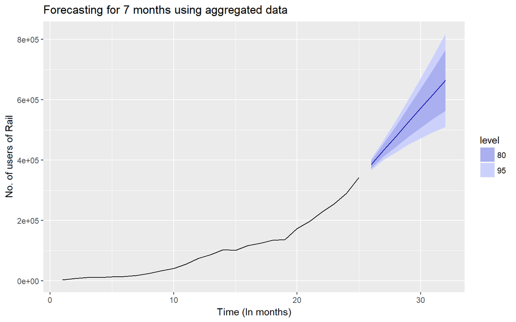

##### **Extraplotting the forecast to find the number of months needed to cross one million users mark**

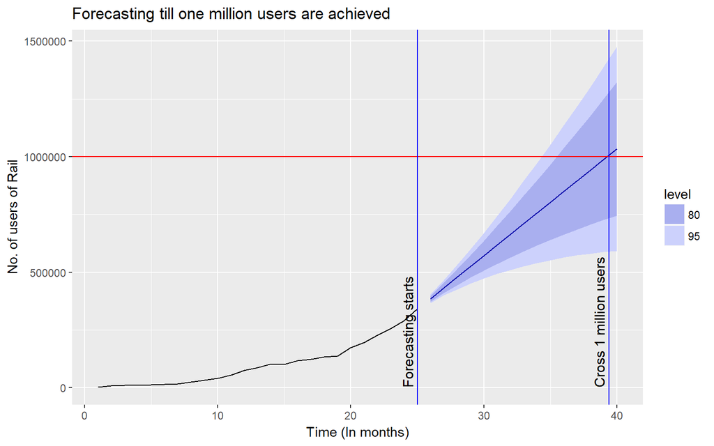

##### From the above plot, it is obvious that the number of people using JetRail as a mode of transportation will cross the one million mark after 15 months provided the given data of past two years.

#### Recommendation

##### Hence, the analysis suggests that Unicorn Investers can go ahead with thier investment in this new mode of high speed transportation method called JetRail.